[figure not shown]

# Machine learning

**Prof. Dr. Fabian Woebbeking**

Assistant Professor of Financial Economics

IWH - Leibniz Institute for Economic Research,

MLU - Martin Luther University Halle-Wittenberg

fabian.woebbeking@iwh-halle.de

## Resources

Books:

- Müller and Guido. Introduction to machine learning with Python: a guide for data scientists.
- Hastie, Tibshirani and Friedman. The elements of statistical learning: data mining, inference, and prediction.
- Kuhn and Johnson. Applied predictive modeling.
- Hal Daumé III. A Course in Machine Learning (Free full text: http://ciml.info/)

Paper:

- Athey, S. "Beyond prediction: Using big data for policy problems." Science 355.6324 (2017): 483-485.
- Athey, S. The Impact of Machine Learning on Economics. The economics of artificial intelligence. University of Chicago Press, 2019. 507-552.
- Athey, S., and G. W. Imbens. Machine learning methods that economists should know about. Annual Review of Economics 11 (2019): 685-725.
- Mullainathan, S., and J. Spiess. Machine learning: an applied econometric approach. Journal of Economic Perspectives 31.2 (2017): 87-106.

## ML in economic research

- Bajari, P., Nekipelov, D., Ryan, S. P., and M. Yang. Machine learning methods for demand estimation. American Economic Review 105.5 (2015): 481-85.
- Burgess, R., Hansen, M., Olken, B. A., and P. Potapov. The Political Economy of Deforestation in the Tropics. Quarterly Journal of Economics 127.4 (2012): 1707-54.
- Engl, F., Riedl, A., and R. Weber. Spillover Effects of Institutions on Cooperative Behavior, Preferences, and Beliefs. Amercian Economic Journal: Microeconomics 13.4 (2021): 261-99.
- Barth, A., Sasan M., and F. Woebbeking. "Let Me Get Back to You” - A Machine Learning Approach to Measuring NonAnswers. Management Science 69.10 (2023): 6333-6348.

## Overview

- https://scikit-learn.org/stable/user_guide.html

### Supervised learning

Some models: https://scikit-learn.org/stable/supervised_learning.html

[figure not shown]

### Unsupervised

Some models: https://scikit-learn.org/stable/unsupervised_learning.html

[figure not shown]

### Reinforcement learning

[figure not shown]

(Watch AlphaGo on Netflix, Prime, ...)

## Universal approximation theorem

The universal approximation theorem states that a neural network with at least one hidden layer and a suitable activation function can approximate **any continuous function** on a compact domain, given sufficiently many neurons.

Therefore, this is not our problem:

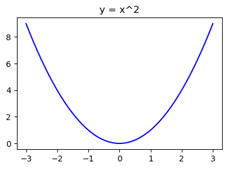

```python
show_xsquared()
```

## Selling your black box

- https://scikit-learn.org/stable/model_selection.html
- Athey, S. "Beyond prediction: Using big data for policy problems." Science 355.6324 (2017): 483-485.

### Cross Validation

[figure not shown]

(Source: https://scikit-learn.org/stable/modules/cross_validation.html)

### Explainable AI (XAI)

Various techniques aiming at

- Model interpretability (vs black box)
- Feature importance:
  - SHAP (SHapley Additive exPlanations)
  - LIME (Local Interpretable Model-agnostic Explanations)
- Visualization

Zoo of methods, e.g. LIME, Anchors, GraphLIME, LRP, DTD, PDA, TCAV, XGNN, SHAP, ASV, Break-Down, Shapley Flow, Textual Explanations of Visual Models, Integrated Gradients, Causal Models, Meaningful Perturbations, and X-NeSyL ... see:

- Holzinger, Andreas, et al. "Explainable AI methods-a brief overview." International Workshop on Extending Explainable AI Beyond Deep Models and Classifiers. Cham: Springer International Publishing, 2020.

# Git(ing) ready

- http://rogerdudler.github.io/git-guide/
- https://guides.github.com/
- https://git-scm.com/book/en/v2
- https://peps.python.org/pep-0008/

[figure not shown]

## Git and GitHub

[figure not shown]

### Git (local repository)

> Git is a free and open source distributed version control system designed to handle everything from small to very large projects with speed and efficiency. [(see Git, 2023)](https://git-scm.com/)

Some source-code editors come with build-in Git (and even GitHub) capabilities or can be extended (e.g. [Microsoft's Visual Studio Code](https://code.visualstudio.com/), which I use during this course).

Your local repository is essentially a folder on your local file system. Changes made in that folder can be committed to the (local) git repository.

First, "stage" your changes - this is sth. like a pre-commit:

```
# The '*' adds all changes made in your local folder
git add *
```

Second, commit your staged changes to the local repository:

```
git commit -m 'Commit message'
```

In the broadest sense, you could see Git as a block chain of commits (changes) made to your repository. You can thus

- observe a complete (almost immutable) history.
- `git checkout` the state at any commit to the repository.

More on Git:

- About Git itself: https://git-scm.com/about
- Getting started (videos, tutorials): https://git-scm.com/doc

### GitHub (remote repository)

You can `clone` the course repository to your local system:

```
git clone https://github.com/cafawo/MachineLearning.git
```

Your local Git repository remembers its origins. This enables you to `pull` updates from the remote (Git does not synchronize automatically).

```
git pull
```

If you have write access to the remote, you can also `push` changes to it.

```
git push
```

Careful: Git tries its best to merge the remote with the local repository, however, might fail if the two repositories are 'too' diverging. This should not concern you too much as a single user, but becomes very relevant when collaborating on a remote.

This is all we need for this course, however, it is only the tip of the iceberg. More on GitHub:

- Working with GitHub (remotes): https://skills.github.com/

## Coding style

Without being too pedantic, we follow the [PEP 8 – Style Guide for Python Code](https://peps.python.org/pep-0008/). When in doubt, return to this source for guidance.

### Naming convention

Here are some best practices to follow when naming stuff.

- Use all lowercase. Ex: `name` instead of `Name`
- One exception: class names should start with a capital letter and follow by lowercase letters.
- Use snake_case convention (i.e., separate words by underscores, look like a snake). Ex: `gross_profit` instead of `grossProfit` or `GrossProfit`.
- Should be meaningful and easy to remember. Ex: `interest_rate` instead of `r` or `ir`.
- Should have a reasonable length. Ex: `sales_apr` instead of `sales_data_for_april`
- Avoid names of popular functions and modules. Ex: avoid `print`, `math`, or `collections`.

### Comments

Comments should help to understand how your code works and your intentions behind it!

> Comments that contradict the code are worse than no comments. Always make a priority of keeping the comments up-to-date when the code changes! Comments should be complete sentences. The first word should be capitalized, unless it is an identifier that begins with a lower case letter (never alter the case of identifiers!). [(PEP 8)](https://peps.python.org/pep-0008/#comments)

# Natural language processing (NLP)

How to squeeze textual data into machine learning methods?

## Bag of words

Taddy, Matt. **"Multinomial inverse regression for text analysis."** Journal of the American Statistical Association 108.503 (2013): 755-770.

```python
# Text input
malory = ["Do you want ants?",
          "Because that’s how you get ants."]

# All unique tokens from the text input (here words, could be n-grams)
feature_names = ['ants', 'because', 'do', 'get', 'how', 'that', 'want', 'you']

feature_matrix = np.array([[1, 0, 1, 0, 0, 0, 1, 1],
                           [1, 1, 0, 1, 1, 1, 0, 1]])

display(pd.DataFrame(feature_matrix, columns=feature_names, index=malory))
```

|  | ants | because | do | get | how | that | want | you |
| --- | --- | --- | --- | --- | --- | --- | --- | --- |
| Do you want ants? | 1 | 0 | 1 | 0 | 0 | 0 | 1 | 1 |
| Because that’s how you get ants. | 1 | 1 | 0 | 1 | 1 | 1 | 0 | 1 |

## Word embedding

Mikolov, Tomas, et al. **"Distributed representations of words and phrases and their compositionality."** Advances in neural information processing systems 26 (2013).

Example: t-distributed Stochastic Neighbor Embedding (TSNE)

[figure not shown]

```python
# Simplified word embeddings for cities and countries
word_embeddings = {
    "Paris": np.array([0.8, 0.2, 0.1]),
    "France": np.array([0.7, 0.2, 0.2]),
    "Berlin": np.array([0.6, 0.4, 0.2]),
    "Germany": np.array([0.6, 0.3, 0.3]),
    "Rome": np.array([0.5, 0.6, 0.2]),
    "Italy": np.array([0.5, 0.5, 0.3])
}

# Function to calculate cosine similarity between two vectors
def cosine_similarity(vec_a, vec_b):
    dot_product = np.dot(vec_a, vec_b)
    norm_a = np.linalg.norm(vec_a)
    norm_b = np.linalg.norm(vec_b)
    return dot_product / (norm_a * norm_b)

print(f"Paris|France: {cosine_similarity(word_embeddings['Paris'], word_embeddings['France']):.2f}")
print(f"Paris|Berlin: {cosine_similarity(word_embeddings['Paris'], word_embeddings['Berlin']):.2f}")
print(f"Paris|Italy:  {cosine_similarity(word_embeddings['Paris'], word_embeddings['Italy']):.2f}")
```

```
Paris|France: 0.99
Paris|Berlin: 0.93
Paris|Italy:  0.83
```

```python
# Vector arithmetic: Berlin - Germany + France
result_vector = word_embeddings["Berlin"] - word_embeddings["Germany"] + word_embeddings["France"]

# Find the closest word to the resulting vector
closest_city = None
max_similarity = -1
for word in ["Paris", "Rome", "Italy"]:
    similarity = cosine_similarity(result_vector, word_embeddings[word])
    if similarity > max_similarity:
        max_similarity = similarity
        closest_word = word

print(f"'Berlin' - 'Germany' + 'France' = '{closest_word}' ({similarity:.2f})")
```

```
'Berlin' - 'Germany' + 'France' = 'Paris' (0.90)
```

## Transformer architecture

Vaswani, Ashish, et al. **"Attention is all you need."** Advances in neural information processing systems 30 (2017).

[figure not shown]

```python
word_embeddings = {
    "Paris": np.array([0.8, 0.2, 0.1]),
    "France": np.array([0.7, 0.3, 0.2]),
    "Berlin": np.array([0.6, 0.1, 0.2]),
    "Germany": np.array([0.6, 0.4, 0.3]),
    "Rome": np.array([0.5, 0.2, 0.2]),
    "Italy": np.array([0.5, 0.5, 0.3])
    }

# This code is just illustrative ... look at the steps, not the code!
def transformer_encoder(word_embeddings):
    # Step 1: Input Embedding
    word_embeddings = word_embeddings

    # Step 2: Positional Encoding
    positional_embeddings = {word: vec + 0.1 for word, vec in word_embeddings.items()}

    # Step 3: Attention
    attention_sum = sum(positional_embeddings.values())
    attention_output = {word: vec * attention_sum for word, vec in positional_embeddings.items()}

    # Step 4: Feed-Forward Network
    feed_forward_output = {word: vec + np.array([0.3, 0.3, 0.3]) for word, vec in attention_output.items()}

    return feed_forward_output
```

```python
def classify_city_country(transformed_embeddings):
    classification = {}
    for word, vec in transformed_embeddings.items():
        # Classification rule: if the second element is greater than 1.2, classify as Country, else as City
        classification[word] = "Country" if vec[1] > 1.2 else "City"
    return classification


# Process the embeddings through the transformer encoder
transformed_embeddings = transformer_encoder(word_embeddings)

# Classify each word as City or Country
classification = classify_city_country(transformed_embeddings)

# Displaying the classification results
for word, category in classification.items():
    print(f"{word} is a {category}")
```

```
Paris is a City
France is a Country
Berlin is a City
Germany is a Country
Rome is a City
Italy is a Country
```

### Fine tuning

- LLMs can be very large, hence, inefficient to train an LLM from scratch
- Fine tune the LLM to a specific task
  - Supervised learning process
  - Update weights of the LLM
- Check out: https://huggingface.co/

### Catastrophic inference/forgetting

- Tendency of neural networks to forget previously learned information upon learning new information
- This creates a problem when updating a model on new data without retraining from scratch (e.g. when fine-tuning a fine-tuned model)
- Common solutions:
  - Regularization methods that penalize changes to important parameters
  - Rehearsal methods that store or generate examples from previous tasks
  - Dynamic architectures that grow or reconfigure network components

## ChatGPT API

```python
# Use your password to log in here ...
with open('gptpassword.txt', 'r') as file:
    openai.api_key = file.read().strip()

#returns a list of all OpenAI models
models = openai.models.list()
print(f"OpenAI currently offers {len(models.data)} models, e.g.:")
display(models.data[0:3])
```

```
OpenAI currently offers 48 models, e.g.:
```

```
[Model(id='gpt-4o-audio-preview-2024-10-01', created=1727389042, object='model', owned_by='system'),
 Model(id='gpt-4o-mini-audio-preview', created=1734387424, object='model', owned_by='system'),
 Model(id='gpt-4o-realtime-preview', created=1727659998, object='model', owned_by='system')]
```

### Prompt engineering

```python
messages = [{"role": "system", "content":
    "You are a helpful assistant."}]
messages.append({"role": "user", "content":
    "Classify into two categories, namely, 'City' and 'Country'"})
messages.append({"role": "user", "content":
    "Classify this: Germany, Paris, France, Berlin, Rome, Italy"})
messages.append({"role": "user", "content":
    "The output should be in JSON format."})
```

### API call

```python
# Send prompt to API and retrieve results
completion = openai.chat.completions.create(
                model="gpt-4", temperature=0.0, seed=2024, messages=messages
            )
print(completion.choices[0].message.content)
```

```
{
  "City": ["Paris", "Berlin", "Rome"],
  "Country": ["Germany", "France", "Italy"]
}
```

API parameters https://platform.openai.com/docs/api-reference

- temperature: "What sampling temperature to use, between 0 and 2. Lower values will make it more focused and deterministic."
- seed: "This feature is in Beta. If specified, **our system will make a best effort to sample deterministically**, such that repeated requests with the same seed and parameters should return the same result."

## Many thanks and happy coding!

fabian.woebbeking@iwh-halle.de